# Using Microsoft R Server for Machine Learning and Modeling

# Modeling with RxSpark

This section shows how to use the `RxSpark` compute context for modeling.

# Locate RevoShare dir

Every MRS installation on a HDFS environment creates a share directory on HDFS. By default, each user will have her own shared directory under the `/user/RevoShare/` file path.

```r
rxHadoopListFiles("/user/RevoShare/")
```

```
[1] "Found 1 items"
[2] "drwxrwxrwx   - alizaidi supergroup          0 2017-05-21 04:12 /user/RevoShare/alizaidi"
[1] TRUE
```

```r
username <- system("whoami", intern = TRUE)
data_path <- file.path("/user/RevoShare", username)
```

# Saving the Spark DataFrame to Parquet File

We will write our Spark DataFrame out to a Parquet file. The other alternative is to save it to persist it in our Hive catalog using `sdf_register`.

## Write Sample Taxi to RevoShare

```r
library(sparklyr)
spark_write_parquet(taxi_binary,
                    path = file.path(data_path, 'TaxiParquet'))
```

## Remove SUCCESS dir

Hadoop is very proud of itself for successfully writing out the Parquet file above. While running, it keeps a file called `_RUNNING` in it’s data directory, and upon completion it writes out a file called `_SUCCESS`. While we are proud of Hadoop as well, we don’t want this file in our data directory upon import, so we’ll trash it.

```r
rxHadoopListFiles(file.path(data_path, "TaxiParquet"))
```

```
 [1] "Found 32 items"
 [2] "-rw-r--r--   1 alizaidi supergroup          0 2017-05-24 13:54 /user/RevoShare/alizaidi/TaxiParquet/_SUCCESS"
 [3] "-rw-r--r--   1 alizaidi supergroup   10495050 2017-05-24 13:54 /user/RevoShare/alizaidi/TaxiParquet/part-r-00000-7f56c7cf-ef80-475d-a5eb-edffafcda8a0.snappy.parquet"
 [4] "-rw-r--r--   1 alizaidi supergroup   10427349 2017-05-24 13:54 /user/RevoShare/alizaidi/TaxiParquet/part-r-00001-7f56c7cf-ef80-475d-a5eb-edffafcda8a0.snappy.parquet"
 [5] "-rw-r--r--   1 alizaidi supergroup   10476692 2017-05-24 13:54 /user/RevoShare/alizaidi/TaxiParquet/part-r-00002-7f56c7cf-ef80-475d-a5eb-edffafcda8a0.snappy.parquet"
 [6] "-rw-r--r--   1 alizaidi supergroup   10509582 2017-05-24 13:54 /user/RevoShare/alizaidi/TaxiParquet/part-r-00003-7f56c7cf-ef80-475d-a5eb-edffafcda8a0.snappy.parquet"
 [7] "-rw-r--r--   1 alizaidi supergroup   10532358 2017-05-24 13:54 /user/RevoShare/alizaidi/TaxiParquet/part-r-00004-7f56c7cf-ef80-475d-a5eb-edffafcda8a0.snappy.parquet"
 [8] "-rw-r--r--   1 alizaidi supergroup   10413896 2017-05-24 13:54 /user/RevoShare/alizaidi/TaxiParquet/part-r-00005-7f56c7cf-ef80-475d-a5eb-edffafcda8a0.snappy.parquet"
 [9] "-rw-r--r--   1 alizaidi supergroup   10487306 2017-05-24 13:54 /user/RevoShare/alizaidi/TaxiParquet/part-r-00006-7f56c7cf-ef80-475d-a5eb-edffafcda8a0.snappy.parquet"
[10] "-rw-r--r--   1 alizaidi supergroup   10398837 2017-05-24 13:54 /user/RevoShare/alizaidi/TaxiParquet/part-r-00007-7f56c7cf-ef80-475d-a5eb-edffafcda8a0.snappy.parquet"
[11] "-rw-r--r--   1 alizaidi supergroup   10418115 2017-05-24 13:54 /user/RevoShare/alizaidi/TaxiParquet/part-r-00008-7f56c7cf-ef80-475d-a5eb-edffafcda8a0.snappy.parquet"
[12] "-rw-r--r--   1 alizaidi supergroup   10405564 2017-05-24 13:54 /user/RevoShare/alizaidi/TaxiParquet/part-r-00009-7f56c7cf-ef80-475d-a5eb-edffafcda8a0.snappy.parquet"
[13] "-rw-r--r--   1 alizaidi supergroup   10454802 2017-05-24 13:54 /user/RevoShare/alizaidi/TaxiParquet/part-r-00010-7f56c7cf-ef80-475d-a5eb-edffafcda8a0.snappy.parquet"
[14] "-rw-r--r--   1 alizaidi supergroup   10486092 2017-05-24 13:54 /user/RevoShare/alizaidi/TaxiParquet/part-r-00011-7f56c7cf-ef80-475d-a5eb-edffafcda8a0.snappy.parquet"
[15] "-rw-r--r--   1 alizaidi supergroup   10628246 2017-05-24 13:54 /user/RevoShare/alizaidi/TaxiParquet/part-r-00012-7f56c7cf-ef80-475d-a5eb-edffafcda8a0.snappy.parquet"
```

[output cut: 19 more lines]

```r
file_to_delete <- file.path(data_path,
                            "TaxiParquet", "_SUCCESS")
delete_command <- paste("fs -rm", file_to_delete)
rxHadoopCommand(delete_command)
```

```
17/05/24 13:54:44 INFO fs.TrashPolicyDefault: Moved: 'wasb://azrsparkdev@azaidihdi.blob.core.windows.net/user/RevoShare/alizaidi/TaxiParquet/_SUCCESS' to trash at: wasb://azrsparkdev@azaidihdi.blob.core.windows.net/user/alizaidi/.Trash/Current/user/RevoShare/alizaidi/TaxiParquet/_SUCCESS
[1] TRUE
```

```r
rxHadoopListFiles(file.path(data_path, "TaxiParquet"))
```

```
 [1] "Found 31 items"
 [2] "-rw-r--r--   1 alizaidi supergroup   10495050 2017-05-24 13:54 /user/RevoShare/alizaidi/TaxiParquet/part-r-00000-7f56c7cf-ef80-475d-a5eb-edffafcda8a0.snappy.parquet"
 [3] "-rw-r--r--   1 alizaidi supergroup   10427349 2017-05-24 13:54 /user/RevoShare/alizaidi/TaxiParquet/part-r-00001-7f56c7cf-ef80-475d-a5eb-edffafcda8a0.snappy.parquet"
 [4] "-rw-r--r--   1 alizaidi supergroup   10476692 2017-05-24 13:54 /user/RevoShare/alizaidi/TaxiParquet/part-r-00002-7f56c7cf-ef80-475d-a5eb-edffafcda8a0.snappy.parquet"
 [5] "-rw-r--r--   1 alizaidi supergroup   10509582 2017-05-24 13:54 /user/RevoShare/alizaidi/TaxiParquet/part-r-00003-7f56c7cf-ef80-475d-a5eb-edffafcda8a0.snappy.parquet"
 [6] "-rw-r--r--   1 alizaidi supergroup   10532358 2017-05-24 13:54 /user/RevoShare/alizaidi/TaxiParquet/part-r-00004-7f56c7cf-ef80-475d-a5eb-edffafcda8a0.snappy.parquet"
 [7] "-rw-r--r--   1 alizaidi supergroup   10413896 2017-05-24 13:54 /user/RevoShare/alizaidi/TaxiParquet/part-r-00005-7f56c7cf-ef80-475d-a5eb-edffafcda8a0.snappy.parquet"
 [8] "-rw-r--r--   1 alizaidi supergroup   10487306 2017-05-24 13:54 /user/RevoShare/alizaidi/TaxiParquet/part-r-00006-7f56c7cf-ef80-475d-a5eb-edffafcda8a0.snappy.parquet"
 [9] "-rw-r--r--   1 alizaidi supergroup   10398837 2017-05-24 13:54 /user/RevoShare/alizaidi/TaxiParquet/part-r-00007-7f56c7cf-ef80-475d-a5eb-edffafcda8a0.snappy.parquet"
[10] "-rw-r--r--   1 alizaidi supergroup   10418115 2017-05-24 13:54 /user/RevoShare/alizaidi/TaxiParquet/part-r-00008-7f56c7cf-ef80-475d-a5eb-edffafcda8a0.snappy.parquet"
[11] "-rw-r--r--   1 alizaidi supergroup   10405564 2017-05-24 13:54 /user/RevoShare/alizaidi/TaxiParquet/part-r-00009-7f56c7cf-ef80-475d-a5eb-edffafcda8a0.snappy.parquet"
[12] "-rw-r--r--   1 alizaidi supergroup   10454802 2017-05-24 13:54 /user/RevoShare/alizaidi/TaxiParquet/part-r-00010-7f56c7cf-ef80-475d-a5eb-edffafcda8a0.snappy.parquet"
[13] "-rw-r--r--   1 alizaidi supergroup   10486092 2017-05-24 13:54 /user/RevoShare/alizaidi/TaxiParquet/part-r-00011-7f56c7cf-ef80-475d-a5eb-edffafcda8a0.snappy.parquet"
[14] "-rw-r--r--   1 alizaidi supergroup   10628246 2017-05-24 13:54 /user/RevoShare/alizaidi/TaxiParquet/part-r-00012-7f56c7cf-ef80-475d-a5eb-edffafcda8a0.snappy.parquet"
[15] "-rw-r--r--   1 alizaidi supergroup   10429116 2017-05-24 13:54 /user/RevoShare/alizaidi/TaxiParquet/part-r-00013-7f56c7cf-ef80-475d-a5eb-edffafcda8a0.snappy.parquet"
```

[output cut: 18 more lines]

# Create HDFS and Spark Contexts for MRS

Let’s create the pointers to the file paths and HDFS to use with the `RxSpark` compute context.

```r
hdfsFS <- RxHdfsFileSystem()
taxi_text <- RxParquetData(file.path(data_path,
                                  "TaxiParquet"),
                           fileSystem = hdfsFS)
taxi_xdf <- RxXdfData(file.path(data_path, "TaxiXdfds"),
                      fileSystem = hdfsFS)
```

## Import to XDF

Now we use our `rxImport` function to import the parquet file into an xdf.

```r
col_classes <- c('VendorID' = "factor",
                 'passenger_count' = "integer",
                 'trip_distance' = "numeric",
                 'RateCodeID' = "factor",
                 'store_and_fwd_flag' = "factor",
                 'payment_type' = "factor",
                 'fare_amount' = "numeric",
                 'tip_amount' = "numeric",
                 'tolls_amount' = "numeric",
                 'pickup_hour' = "factor",
                 'pickup_dow' = "factor",
                 'dropoff_hour' = "factor",
                 'dropoff_dow' = "factor",
                 'pickup_nhood' = "factor",
                 'dropoff_nhood' = "factor",
                 'kSplits' = "factor",
                 'tip_pct' = "numeric",
                 'good_tip' = "factor")
rxImport(inData = taxi_text, taxi_xdf, colClasses = col_classes)
```

## Simple EDA

```r
tip_dist_df <- rxCube(tip_pct ~ pickup_hour + pickup_dow,
                      data = taxi_xdf, returnDataFrame = TRUE)
```

```
======  ed0-azrspa (Master HPA Process) has started run at Wed May 24 14:01:45 2017  ======
17/05/24 14:01:46 WARN util.NativeCodeLoader: Unable to load native-hadoop library for your platform... using builtin-java classes where applicable
Computation time: 14.111 seconds.
======  ed0-azrspa (Master HPA Process) has completed run at Wed May 24 14:02:06 2017  ======
Warning message:
In rxLinkFormulaComponents(formula = formula, fweights = fweights,  :
  Please use ':' instead of '+' to separate the independent variables: 'tip_pct ~ pickup_hour + pickup_dow'
```

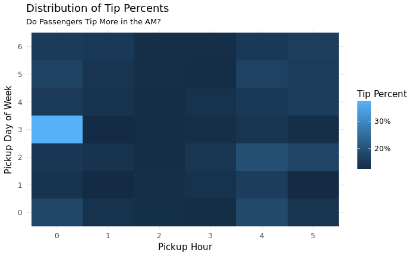

```r
library(ggplot2)
library(magrittr)
tip_dist_df %>% ggplot(aes(x = pickup_hour, y = pickup_dow, fill = tip_pct)) +
  geom_tile() + theme_minimal() +
  scale_fill_continuous(label = scales::percent) +
  labs(x = "Pickup Hour", y = "Pickup Day of Week", fill = "Tip Percent",
      title = "Distribution of Tip Percents",
      subtitle = "Do Passengers Tip More in the AM?")
```

# Creating Linear Models

Let’s predict tip_pct as a function of distance and neighborhoods. In order to ensure that the neighbhorhood columns are treated as categorical, we will first convert them to factors. `RevoScaleR` and the `RxSpark` compute context are more picky about factor types than base R models, since they utilize data that is chunked and stored in distributed file systems.

```r
system.time(linmod <- rxLinMod(tip_pct ~ pickup_nhood +  trip_distance,
                               data = taxi_xdf, cube = TRUE))
```

```
======  ed0-azrspa (Master HPA Process) has started run at Wed May 24 14:02:16 2017  ======
17/05/24 14:02:17 WARN util.NativeCodeLoader: Unable to load native-hadoop library for your platform... using builtin-java classes where applicable
Computation time: 12.872 seconds.
======  ed0-azrspa (Master HPA Process) has completed run at Wed May 24 14:02:35 2017  ======
   user  system elapsed
  1.272   0.828  28.421
```

```r
system.time(linmod <- rxLinMod(tip_pct ~ pickup_nhood + pickup_hour + trip_distance,
                               data = taxi_xdf, cube = TRUE))
```

```
======  ed0-azrspa (Master HPA Process) has started run at Wed May 24 14:02:44 2017  ======
17/05/24 14:02:45 WARN util.NativeCodeLoader: Unable to load native-hadoop library for your platform... using builtin-java classes where applicable
Computation time: 12.917 seconds.
======  ed0-azrspa (Master HPA Process) has completed run at Wed May 24 14:03:04 2017  ======
   user  system elapsed
  1.168   0.904  28.440
```

## Creating Decision and Ensemble Trees

```r
system.time(dtree <- rxDTree(good_tip ~ trip_distance + passenger_count,
                                 data = taxi_xdf, method = "class"))
```

[output not shown]

[output cut: 15 more lines]

[output not shown]

```r
# plot(RevoTreeView::createTreeView(dtree))
#
# system.time(dforest <- rxDForest(good_tip ~ pickup_nhood + pickup_hour + trip_distance,
#                                  data = taxi_xdf, method = "class"))
```

## Publish to AzureML

We can use the [`AzureML`](https://github.com/RevolutionAnalytics/AzureML) package to convert our trained model as an Azure API. You’ll need to get your security credentials from [AzureML Studio](https://studio.azureml.net). Click on *Settings*, copy *Workspace ID*. Then click on *Authorization Tokens* at the top header, and copy your *Primary Authorization Token*.

```r
packageVersion("AzureML")
library(AzureML)
ws <- workspace(
  id = "----",
  auth = "------"
)

head(datasets(ws))
AzureML::experiments(ws)
```

As of right now (March 2017), AzureML does not have `rx` functions from the `RevoScaleR` package. Therefore, we need to convert our `RevoScaleR` model into a model that GNU-R/MRO can understand. Fortunately, the `RevoScaleR` modeling functions have methods to convert `rx` models into CRAN equivalents:

```r
rpartModel <- as.rpart(dtree)
```

Now let’s create a scoring function:

```r
scoringFn <- function(testdata) {

  library(rpart)
  predict(rpartModel, newdata = testdata)[, 1]

}
```

and let’s copy into a data.frame a portion of our training data to use as our schema:

```r
library(dplyr)
exampleDF <- head(taxi_xdf) %>% select(trip_distance, passenger_count)
```

Let’s make sure our scoring function works locally first:

```r
scoringFn(exampleDF)
```

We’re ready to operationalize our model:

```r
endpoint <- publishWebService(ws,
                              fun = scoringFn,
                              name = "Taxi-tip-rpart",
                              inputSchema = exampleDF)
```

Let’s try it out:

```r
scores <- consume(endpoint, exampleDF)
head(scores)
```